# Data visualization hands-on session

Alan Lorenzetti

8/11/2020

# 1 Introduction

In this session we will cover a few topics on data visualization.

**1.** We are going to reproduce a protein-protein interaction network I’ve made for a paper published recently. For that, we are going to use Cytoscape.

**2.** We will explore different types of variables and plot them using the R language environment. More specifically we will use RStudio Cloud and a package called `ggplot2`.

# 2 Network visualization using Cytoscape

## 2.1 Context

In de Lomana et al. (2020), we studied the aspects of the translational regulation of *Halobacterium salinarum*. One of the questions we needed to answer to support one of our hypothesis was:

- Is transcription and translation coupled in *H. salinarum*?

We know that transcription and translation happen in different compartments in the eukaryotic cell: Transcription happens inside the nuclei. Translation happens in the cytoplasm.

In the prokaryotic cell, we don’t have a membrane to separate the genetic material from the cytoplasm, so transcription and translation are likely to happen simultaneously. Coupled transcription and translation is a fact in Bacteria. But what about Archaea?

[figure not shown]

Source: https://www.mun.ca/biology/scarr/iGen3_05-09.html

In the Baliga Lab, a few years ago, Mark Facciotti and his colleagues performed a target coimmunoprecipitation experiment to find out what were the proteins coupled to specific proteins of the transcription machinery, the general transcription factors of *H. salinarum*. [Facciotti et al. 2007].

Using those results, we checked if proteins of the translational machinery were present in the pulldown fractions of transcription proteins. Indeed, we were able to find a few, supporting our hypothesis of coupled transcription and translation:

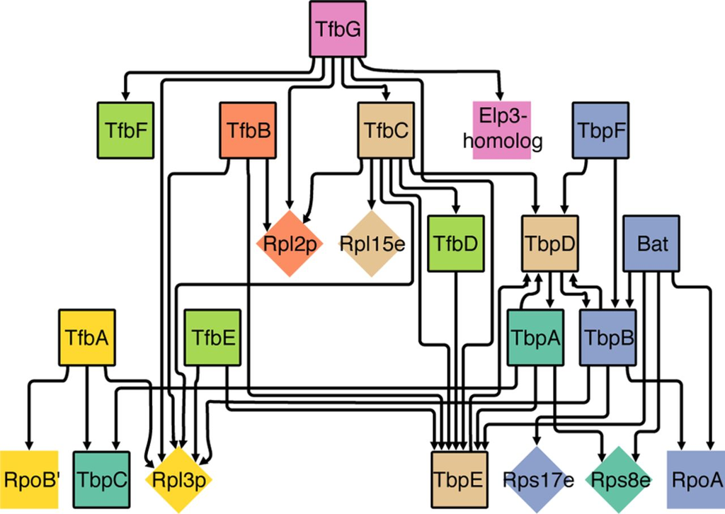

RPs physically interact with transcription complex components. Diamonds represent RPs; squares represent transcription complex components. Tagged proteins used as bait in the immunoprecipitation experiment are highlighted by a black border. Arrowheads link bait to coimmunoprecipitated proteins. We labeled each of the seven modules obtained by the Newman-Girvan clustering algorithm using a different color [de Lomana et al., 2020].

## 2.2 Data structure

### 2.2.1 Protein-protein interaction network

This is the structure of a Simple Interaction File (SIF)

|  | bait | interaction | protein |
| --- | --- | --- | --- |
| 1 | VNG5039G | pullsdown | VNG5142G |
| 2 | VNG5039G | pullsdown | VNG2218G |
| 3 | VNG5039G | pullsdown | VNG6313G |
| 4 | VNG5039G | pullsdown | VNG1149Cm |
| 5 | VNG5039G | pullsdown | VNG1933G |
| 6 | VNG5039G | pullsdown | VNG0209H |
| 7 | VNG5039G | pullsdown | VNG5163G |
| 8 | VNG5039G | pullsdown | VNG1932G |
| 9 | VNG5039G | pullsdown | VNG6029G |
| 10 | VNG5039G | pullsdown | VNG2473G |

[output cut: 218 more lines]

### 2.2.2 Protein information

|  | ID | label | is_bait | product | class |
| --- | --- | --- | --- | --- | --- |
| 1 | VNG5039G | TbpA | True | Product Unknown | Transcription |
| 2 | VNG5142G | TbpC | True | Product Unknown | Transcription |
| 3 | VNG2218G | VNG2218G | False | 2-oxo-3-methylvalerate dehydrogenase E1component beta subunit | Glycolysis / Gluconeogenesis |
| 4 | VNG6313G | VNG6313G | False | arginine/ornithine antiporter | Class Unknown |
| 5 | VNG1149Cm | VNG1149Cm | False | Product Unknown | Class Unknown |
| 6 | VNG1933G | VNG1933G | False | FtsZ family protein CetZ, type III | Class Unknown |
| 7 | VNG0209H | VNG0209H | False | uncharacterized protein | Class Unknown |
| 8 | VNG5163G | TbpD | True | Product Unknown | Transcription |
| 9 | VNG1932G | VNG1932G | False | arNOG06768 family NADH-binding domain protein | Oxidative phosphorylation |
| 10 | VNG6029G | VNG6029G | False | gas-vesicle major structural protein GvpA | Class Unknown |

[output cut: 118 more lines]

## 2.3 Installing Cytoscape and apps (or plugins)

**1.** Go to the Cytoscape [download page](https://cytoscape.org/download.html). Download and install it.

**2.** Open Cytoscape program and install the following apps:

- clusterMaker2  
  `Apps -> App Manager -> Search: clusterMaker2 -> Select listing -> Click on Install button`
- Color Cast  
  `Apps -> App Manager -> Search: Color Cast -> Select listing -> Click on Install button`
- yFiles Layout Algorithms  
  `Apps -> App Manager -> Search: yFiles -> Select listing -> Click on Install button`

## 2.4 Plotting a protein-protein interaction network

**1.** Import the protein-protein interaction file `ppi.sif`.  
`File -> Import -> Network from URL ->`  
`https://alanlorenzetti.github.io/dataVisSession2020/data/ppi.sif`

**2.** Import the protein information table.  
`File -> Import -> Table from URL ->` `https://alanlorenzetti.github.io/dataVisSession2020/data/ppiFunCat.tsv ->`  
`Where to Import Table Data: To selected networks only -> Click on OK button`

**3.** Click on `Style` tab. Let’s change the design of our network.

- Select the `Sample1` preset style.
- Change the label of nodes by selecting the `label` column.
- Change the shape of nodes according to the functional `class` of proteins. Rectangles will represent `Transcription` class. Diamonds will represent `Translation` class.
- Add a thick border to the nodes of proteins used as baits. Set size `2`.
- Make the nodes bigger. Select size `35`.
- Click on the `Edge` tab. Make the edges thicker (size `1.5`) and `black`.
- Add arrowheads (`Target Arrow Shape; Delta`) to the end of edges.
- Remove edge labels.

**4.** Apply the Newman-Girvan modularity algorithm to find modules of highly interconnected proteins. Use the default parameters. `Apps -> clusterMaker -> Community Cluster (GLay)`

**5.** Change the color of nodes according to the modules. We will use a plugin called `Color Cast` to make our lives easier. Select `__glayCluster` as the target data column. We’ll apply the `Set2` colors. `Tools -> Color Cast -> Color Cast`

**6.** Remove all the nodes not classified as `Transcription` or `Translation`.

- Using the `Node Table` panel, order the class column and select all proteins of those classes.
- Then right-click the selection and then click on `Select nodes from selected rows`.
- Hide the unselected nodes. `Select -> Nodes -> Hide Unselected Nodes`.

**7.** Apply an automatic layout.

- Select all proteins used as baits (those with borders).
- Apply `yFiles Hierarchic Layout Selected Nodes`. `Layouts -> Hierarchic Layout Selected Nodes`.

**8.** Save your network and export as an image file.

- `File -> Save`
- `File -> Export -> Network to Image`

# 3 Data visualization in R using the `ggplot2` package

## 3.1 Installing `ggplot2` package

```r
#install.packages("ggplot2")
library(ggplot2)
theme_set(theme_bw())

haloExp = read.delim("data/haloExpression.tsv")
```

## 3.2 Variable types

### 3.2.1 Discrete variables

- Counts:
  - The number of times you cursed this damn virus this week (5)
  - Number of stars in the Milky Way (250 billion or 2.5 x 10^11)
  - Number of genes in a genome (2600)
  - Number of messenger RNA molecules in a bacterial cell (~1800) [Moran et al. 2013]
  - Length of a messenger RNA (1573 nucleotides)

### 3.2.2 Continuous variables

- Measures:
  - Height of an individual (162.56 centimeters)
  - Weight of an individual (89.77 kilograms)
- Ratios:
  - GC content, i.e., frequency of Guanine or Cytosine bases in a transcript (e.g. 973/1573 = 0.619)

### 3.2.3 Categorical variables

- Characteristics:
  - Color of eyes (black, brown, blue, green, red)
  - Transcript type (protein coding, transporter RNA, ribosomal RNA)

## 3.3 Data structure

|  | ID | protein_product | biological_class | mRNA_expression | protein_expression | length | GC |
| --- | --- | --- | --- | --- | --- | --- | --- |
| 1 | VNG_0001H | uncharacterized protein | Cell wall/membrane/envelope biogenesis | 3.43723963450264 | 3.3010121054195 | 1206 | 0.653399668325041 |
| 2 | VNG_0002G | ABC-type transport system ATP-binding protein(probable substrate macrolides) | Defense mechanisms | 3.30853056322762 | 2.30560742694549 | 666 | 0.648648648648649 |
| 3 | VNG_0003C | ABC-type transport system permease protein(probable substrate macrolides) | Defense mechanisms | 3.21712510970415 | 1.85555417100523 | 1143 | 0.628171478565179 |
| 4 | VNG_0005H | uncharacterized protein | Cell wall/membrane/envelope biogenesis | 2.42686166244884 | 2.60642829466211 | 2322 | 0.699827734711456 |
| 5 | VNG_0006G | glutamine-fructose-6-phosphate transaminase | Cell wall/membrane/envelope biogenesis | 2.97695468360652 | 2.52040703595317 | 1806 | 0.691029900332226 |
| 6 | VNG_0008G | sugar nucleotidyltransferase | Cell wall/membrane/envelope biogenesis | 2.81077305516509 | 2.64149114970392 | 1188 | 0.691919191919192 |
| 7 | VNG_0009G | sugar nucleotidyltransferase | Cell wall/membrane/envelope biogenesis | 2.4537123967014 | 2.76545812071155 | 1206 | 0.692371475953566 |
| 8 | VNG_0011C | sugar transferase | Cell wall/membrane/envelope biogenesis | 2.70873630546397 | 2.18497438202749 | 1434 | 0.663179916317992 |
| 9 | VNG_0013C | IS1341-type transposase ISH37 | Mobilome: prophages, transposons | 4.14553575887208 | 1.69769286154141 | 1257 | 0.607000795544948 |
| 10 | VNG_0015H | PemK family protein | Defense mechanisms | 2.54023885664806 | 1.83773754427412 | 351 | 0.592592592592593 |

[output cut: 2340 more lines]

## 3.4 Syntax

## 3.5 Visualizations

### 3.5.1 Histograms

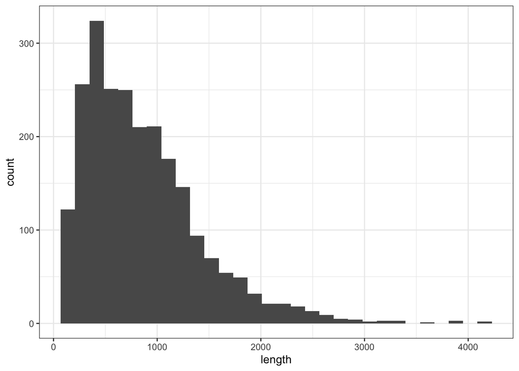

```r
ggplot(data = haloExp, mapping = aes(x = length)) +
  geom_histogram()
```

### 3.5.2 Density curves

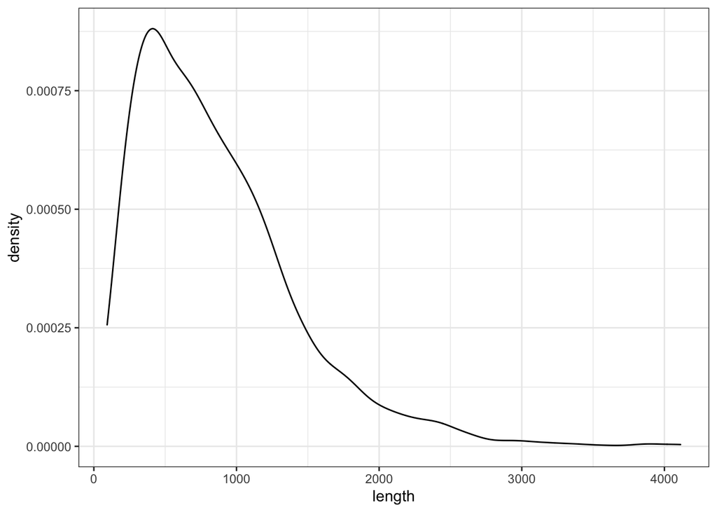

```r
ggplot(data = haloExp, mapping = aes(x = length)) +
  geom_density()
```

### 3.5.3 Bar plots

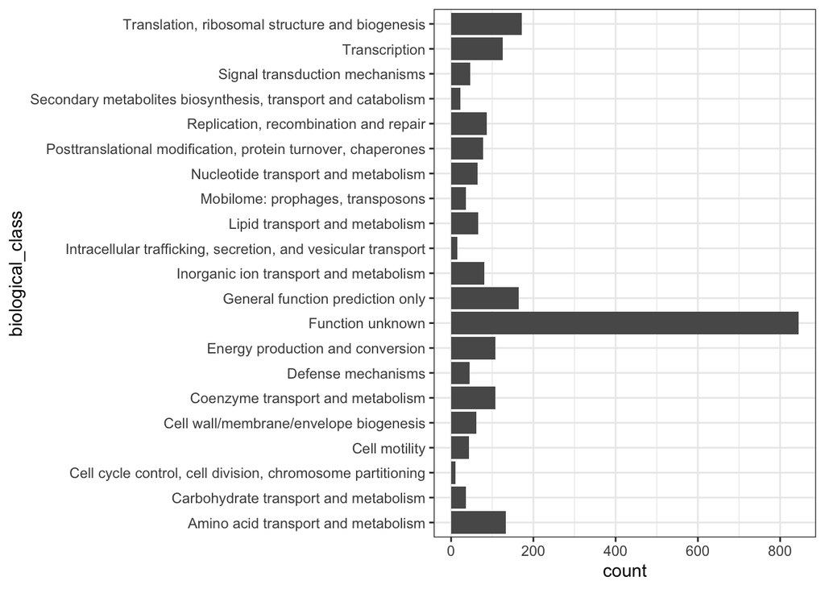

```r
ggplot(data = haloExp, mapping = aes(x = biological_class)) +
  geom_bar() +
  coord_flip()
```

### 3.5.4 Boxplots

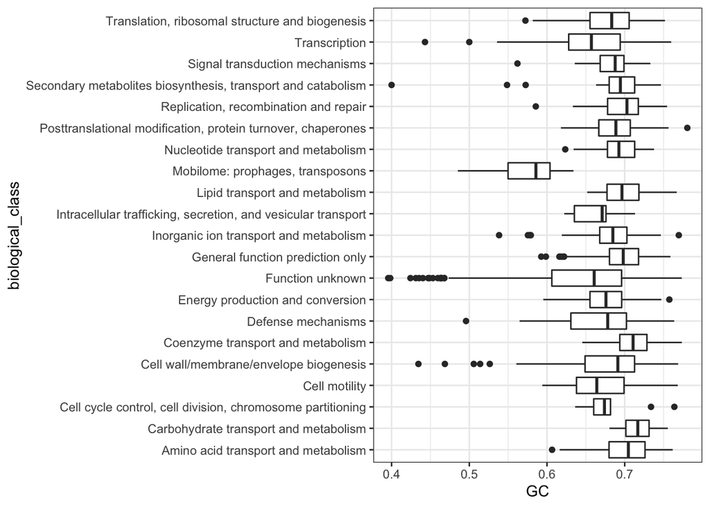

```r
ggplot(data = haloExp, mapping = aes(y = GC, x = biological_class)) +
  geom_boxplot() +
  coord_flip()
```

### 3.5.5 Scatter plots

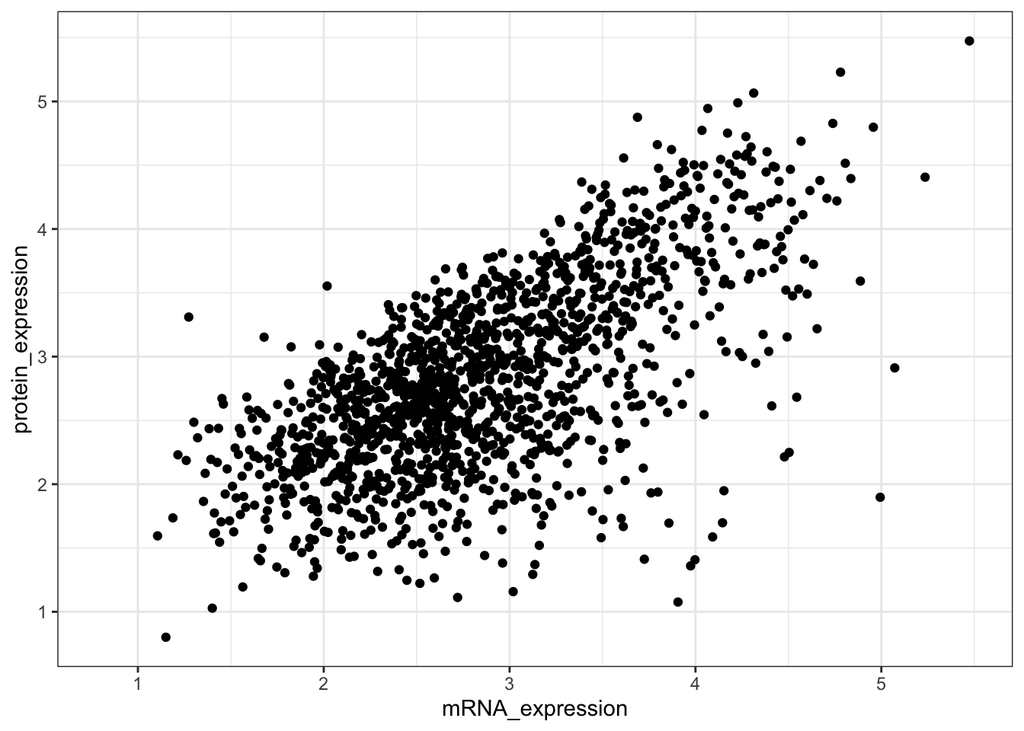

```r
ggplot(data = haloExp, mapping = aes(x = mRNA_expression, y = protein_expression)) +
  geom_point()
```

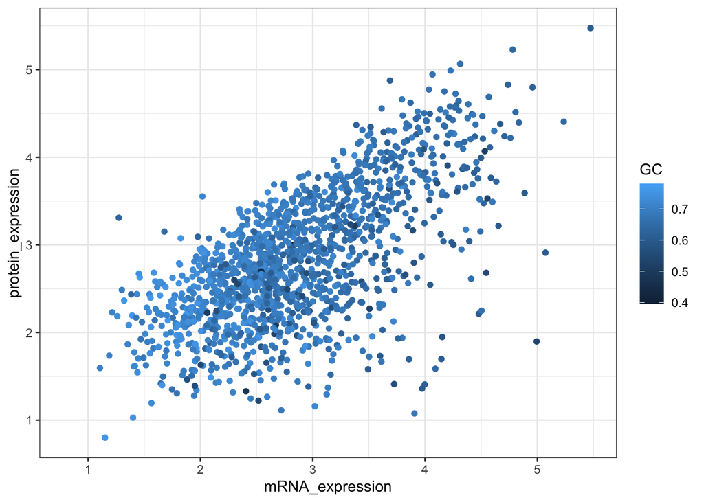

```r
ggplot(data = haloExp, mapping = aes(x = mRNA_expression, y = protein_expression, color = GC)) +
  geom_point()
```

### 3.5.6 3D scatter plots

### 3.5.7 Heat maps

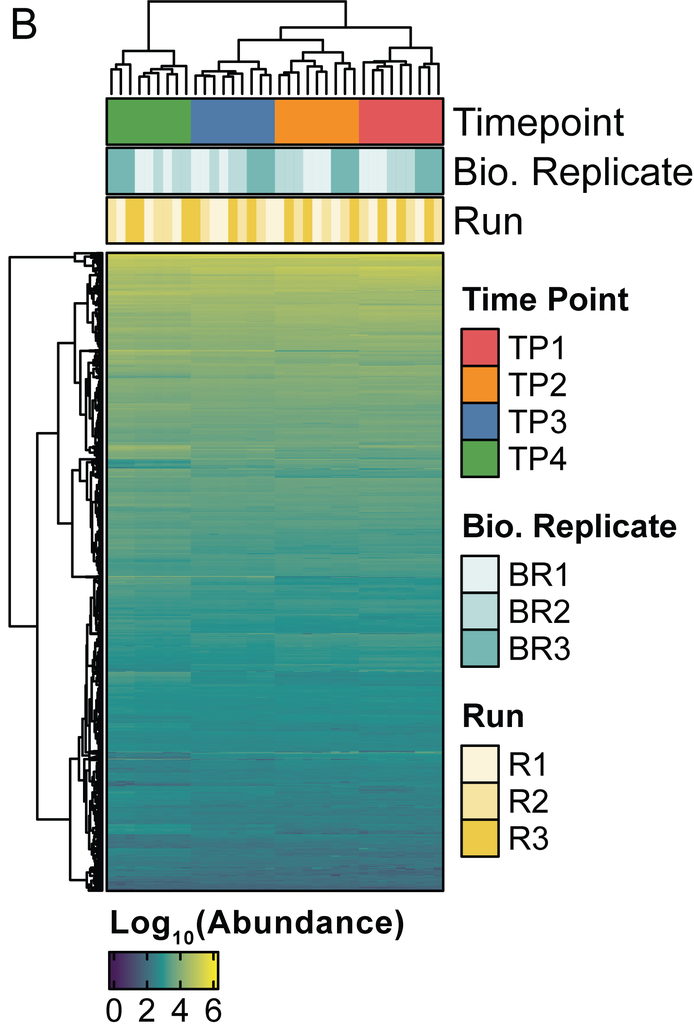

## 3.6 Exercises

- Plot a density curve of the GC variable.

# 4 Resources

- [RStudio IDE cheatsheet](https://github.com/rstudio/cheatsheets/raw/master/rstudio-ide.pdf)
- [`ggplot2` cheatsheet](https://github.com/rstudio/cheatsheets/raw/master/data-visualization-2.1.pdf)

# 5 References

DE LOMANA, A. et al. Selective Translation of Low Abundance and Upregulated Transcripts in Halobacterium salinarum. mSystems, v. 5, n. 4, 28 jul. 2020.

FACCIOTTI, M. T. et al. General transcription factor specified global gene regulation in archaea. Proceedings of the National Academy of Sciences of the United States of America, v. 104, n. 11, p. 4630–4635, 13 mar. 2007.

MORAN, M. A. et al. Sizing up metatranscriptomics. The ISME Journal, v. 7, n. 2, p. 237–243, fev. 2013.